# Лабораторная работа №13

Администрирование локальных сетей

Ибрахим Мохсейн Алькамаль

1032225432@rudn.ru

Российский университет дружбы народов

2026-05-09

# Информация

## Докладчик

- Ибрахим Мохсейн Алькамаль
- Российский университет дружбы народов
- [GitHub](https://github.com/Ebrahimalkamal2027)

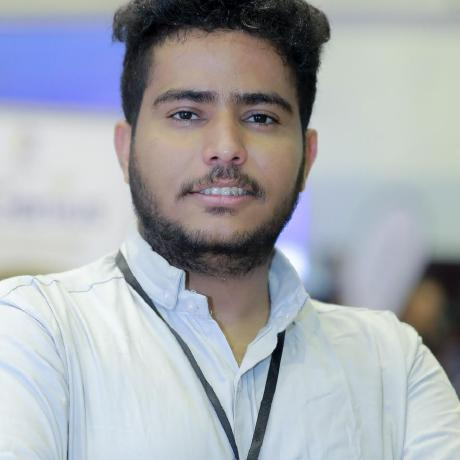

# Цель работы

- Подготовка локальной сети к подключению к Интернету
- Построение схем L1, L2 и L3
- Моделирование сети провайдера и сети Интернет в Cisco Packet Tracer

# Выполнение лабораторной работы

## Построение схемы L1 сети

- Сформирована схема L1 сети
- Добавлена сеть провайдера
- Добавлена модельная сеть Интернет
- Указаны маршрутизаторы, коммутаторы, медиаконвертеры и серверы
- Обозначены интерфейсы подключения

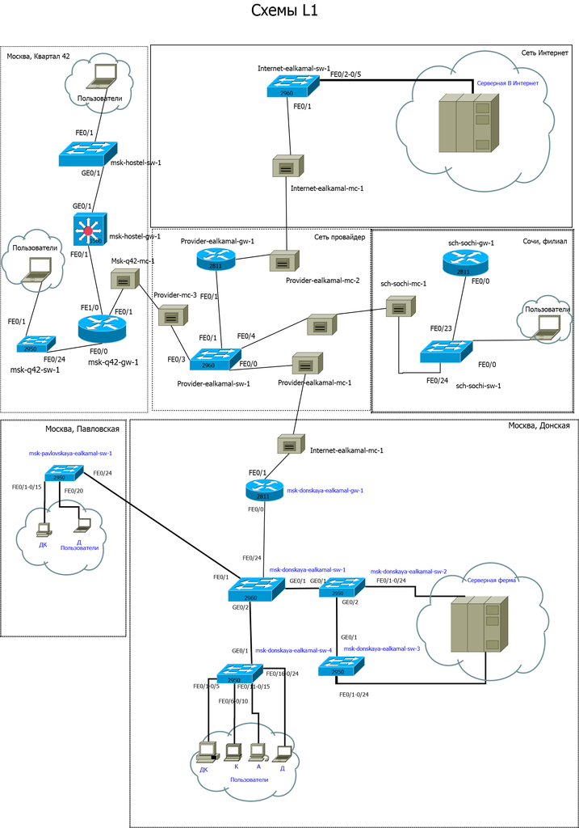

Рисунок 1: Схема L1 сети с подключением провайдера и модельного Интернета

## Построение схемы L2 сети

- Разработана схема L2 сети
- Указаны VLAN различных сегментов сети
- Отображены VLAN локальной сети
- Добавлены VLAN сети провайдера
- Показаны соединения с модельной сетью Интернет

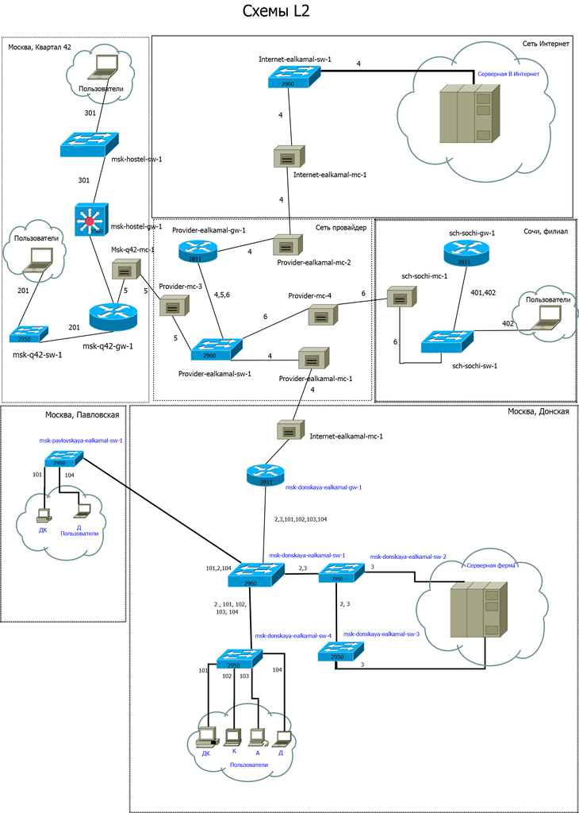

Рисунок 2: Схема L2 сети с распределением VLAN

## Построение схемы L3 сети

- Построена схема L3 сети
- Настроена IP-адресация локальных сетей
- Указаны адреса каналов связи
- Использована подсеть 192.0.2.0/24 для Интернета
- Использована подсеть 198.51.100.0/28 для сети провайдера

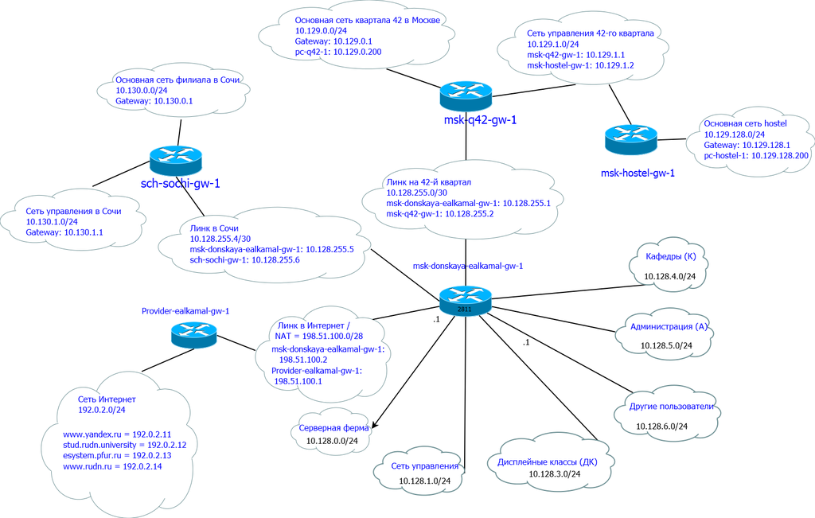

Рисунок 3: Схема L3 сети с IP-адресацией

## Настройка медиаконвертеров

- Выполнена замена стандартных модулей
- Установлены модули PT-REPEATER-NM-1FFE
- Установлены модули PT-REPEATER-NM-1CFE
- Подготовено подключение Fast Ethernet и оптоволокна

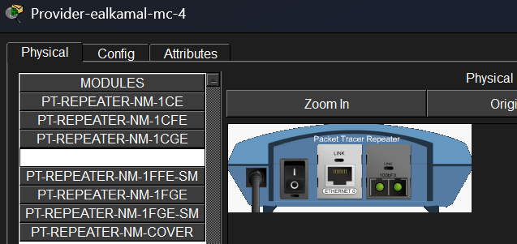

Рисунок 4: Настройка модулей медиаконвертера

## Проверка интерфейсов маршрутизатора

- Проверена конфигурация интерфейсов маршрутизатора
- Проверены установленные сетевые модули
- Подтверждена готовность подключения к сети провайдера

[figure not shown]

Рисунок 5: Физические интерфейсы маршрутизатора Cisco 2811

## Настройка физической рабочей области

- В физической области Packet Tracer добавлено здание Q42
- Организованы соединения между объектами
- Соединения выполнены по разработанной схеме сети

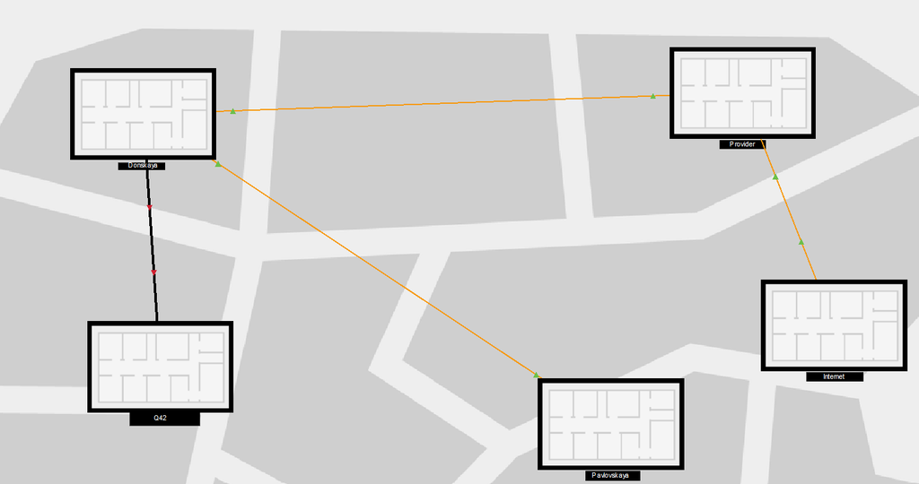

Рисунок 6: Физическая схема соединения зданий в Packet Tracer

## Создание здания филиала в Сочи

- Создано отдельное здание филиала в Сочи
- Подготовлено размещение оборудования удалённой сети

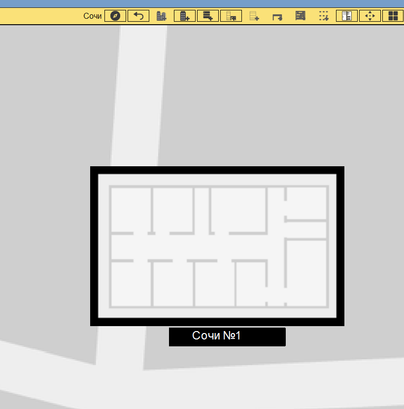

Рисунок 7: Здание филиала сети в Сочи

## Соединение физических площадок

- Выполнено соединение площадок Moscow и Сочи
- Создана общая физическая топология сети

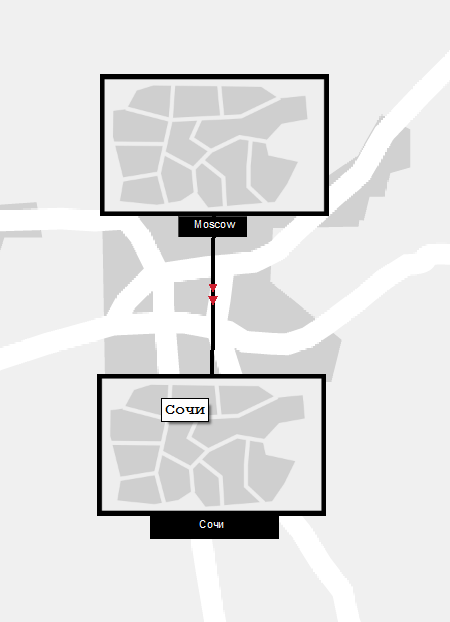

Рисунок 8: Соединение физических площадок Moscow и Сочи

## Первоначальная настройка маршрутизатора msk-q42-ealkamal-gw-1

- Назначено имя маршрутизатора
- Настроены пароли консоли и VTY
- Создан пользователь admin
- Настроен SSH-доступ
- Сгенерированы RSA-ключи

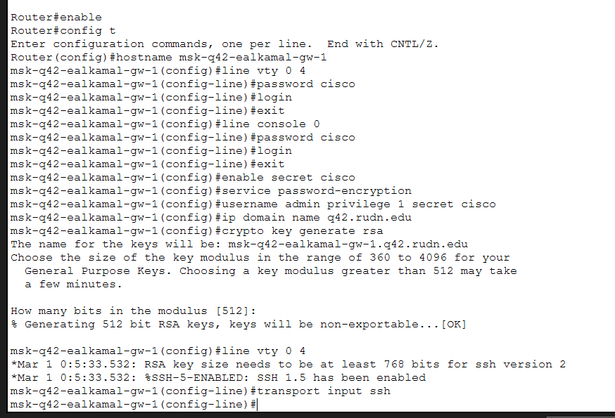

Рисунок 9: Первоначальная настройка маршрутизатора msk-q42-ealkamal-gw-1

## Первоначальная настройка коммутатора msk-q42-ealkamal-sw-1

- Настроен удалённый доступ
- Настроен консольный доступ
- Настроен SSH-доступ
- Выполнена генерация RSA-ключей

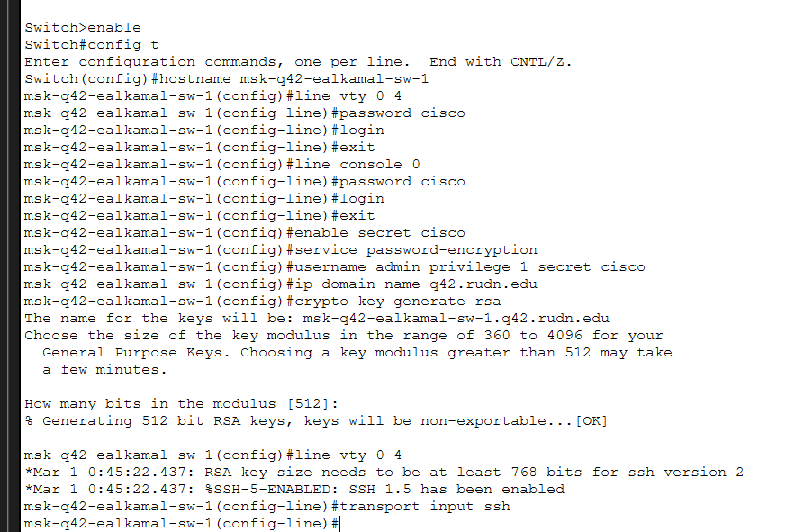

Рисунок 10: Первоначальная настройка коммутатора msk-q42-ealkamal-sw-1

## Настройка маршрутизатора msk-hostel-ealkamal-gw-1

- Настроено имя устройства
- Настроены пароли доступа
- Настроен SSH-доступ
- Выполнена генерация RSA-ключей

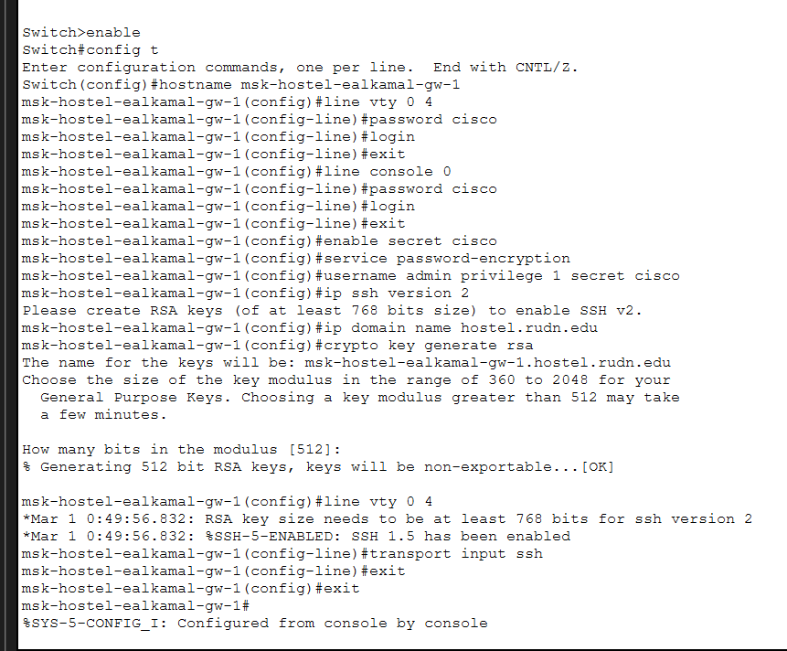

Рисунок 11: Настройка маршрутизатора msk-hostel-ealkamal-gw-1

## Настройка коммутатора msk-hostel-ealkamal-sw-1

- Настроен SSH-доступ
- Выполнено сохранение конфигурации
- Конфигурация сохранена в энергонезависимой памяти

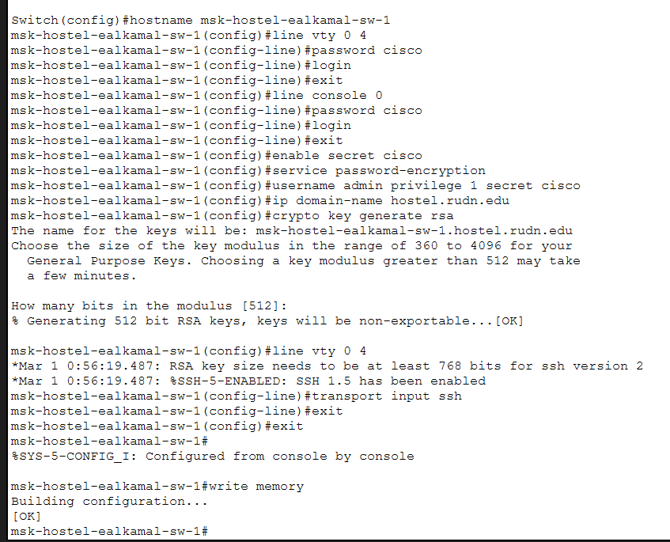

Рисунок 12: Настройка коммутатора msk-hostel-ealkamal-sw-1

## Настройка коммутатора sch-sochi-ealkamal-sw-1

- Выполнена базовая настройка коммутатора
- Настроен SSH-доступ
- Сгенерированы RSA-ключи

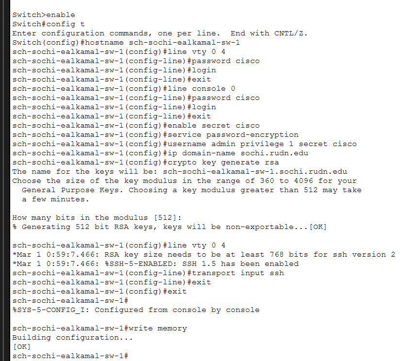

Рисунок 13: Настройка коммутатора sch-sochi-ealkamal-sw-1

## Настройка маршрутизатора sch-sochi-ealkamal-gw-1

- Настроен SSH-доступ
- Выполнена настройка удалённого администрирования
- Сгенерированы RSA-ключи

[figure not shown]

Рисунок 14: Настройка маршрутизатора sch-sochi-ealkamal-gw-1

## Итоговая логическая топология сети

- Сформирована итоговая логическая топология
- Объединены локальные подсети
- Добавлена сеть провайдера
- Добавлена модельная сеть Интернет
- Подключены серверы и медиаконвертеры
- Настроены межсетевые соединения

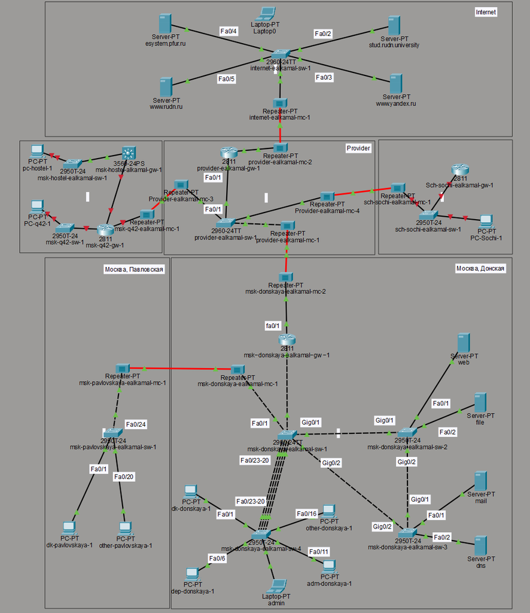

Рисунок 15: Итоговая логическая топология сети в Packet Tracer

# Выводы

- Разработаны схемы L1, L2 и L3
- Выполнено моделирование сети провайдера
- Выполнено моделирование сети Интернет
- Размещено оборудование в физической области Packet Tracer
- Выполнена первоначальная настройка сетевых устройств
- Подготовлена инфраструктура для дальнейшей настройки NAT